# Linear Models with R Notes

# Chapter 1 - Introduction

## 1.2 Initial Data Analysis

**This is a critical step that should always be performed.**

You should make numerical summaries (means, standard deviations, max/min, correlations, etc.), whatever is appropriate to the dataset

The `summary()` command is a quick and easy way to get usual univariate summary info to look for anything glaringly unexpected

# graphical summaries are equally important

**For one variable at a time:** - boxplots

- histograms
- density plots
- more

**For two variables** - scatterplots are standard

- interactive plots good for more than 2 variables

Here is the data I will be working with

```r
library(readxl)
library(kableExtra)
library(dplyr)

df = read_excel("C:/Users/bbarrineau/Desktop/Complete Harvest Set - with B2021.xlsx", sheet= "SASDataRounded")
kbl(sample_n(df,7)) %>%
  kable_styling(bootstrap_options = c("striped"))
```

| Plot | Rep | Trt | Trt 2 | GTcwtA | A123cwtA | PercentC | PercentB | PercentA1 | PercentA2 | PercentA3 | Percent A4 | Percent A13 | Percent A23 | SG | PercentGreen | PercentGC | PercentMis | PercentRots | PercentTotal PO | PercentHH | PercentCRS | PercentIHN | PercentBC |
| --- | --- | --- | --- | --- | --- | --- | --- | --- | --- | --- | --- | --- | --- | --- | --- | --- | --- | --- | --- | --- | --- | --- | --- |
| H1-495 | 3 | 12 | NA | 689 | 50 | 32 | 27 | 0 | 13 | 0 | 0 | 13 | 13 | 1.076 | 0 | 0 | 7 | 6 | 12 | 0 | 0 | 0 | 0 |
| F7-41 | 3 | 0 | NA | 1256 | 216 | 6 | 6 | 0 | 57 | 0 | 0 | 57 | 57 | 1.087 | 0 | 1 | 0 | 1 | 2 | 0 | 0 | 0 | 0 |
| I2-24 | 1 | 24 | NA | 1188 | 170 | 9 | 16 | 0 | 25 | 0 | 0 | 25 | 25 | 0.000 | 0 | 0 | 0 | 4 | 4 | 0 | 0 | 0 | 0 |
| J2-50 | 3 | 2 | NA | 813 | 138 | 7 | 5 | 0 | 50 | 0 | 0 | 50 | 50 | 0.000 | 1 | 0 | 0 | 3 | 4 | 0 | 0 | 0 | 0 |
| H3-479 | 1 | 46 | NA | 1116 | 197 | 5 | 3 | 0 | 34 | 0 | 0 | 34 | 34 | 1.070 | 0 | 0 | 0 | 4 | 4 | 0 | 0 | 0 | 0 |
| N2-40 | 1 | 40 | NA | 808 | 68 | 35 | 18 | 0 | 32 | 0 | 0 | 32 | 32 | 1.061 | 0 | 6 | 0 | 5 | 12 | 0 | 0 | 0 | 0 |
| R1-57 | 1 | 57 | NA | 1419 | 152 | 18 | 24 | 5 | 26 | 0 | 0 | 30 | 26 | 1.094 | 5 | 0 | 0 | 2 | 7 | 0 | 0 | 0 | 0 |

Here are some quick graphical summary options

```r
par(mfrow = c(1,3))
hist(df$PercentC)
plot(density(df$PercentC, na.rm = TRUE))
```

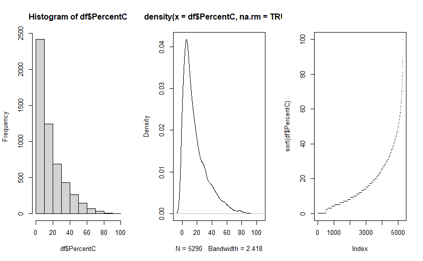

```r
plot(sort(df$PercentC), pch = ".")
```

Here are some more for bivariate datasets

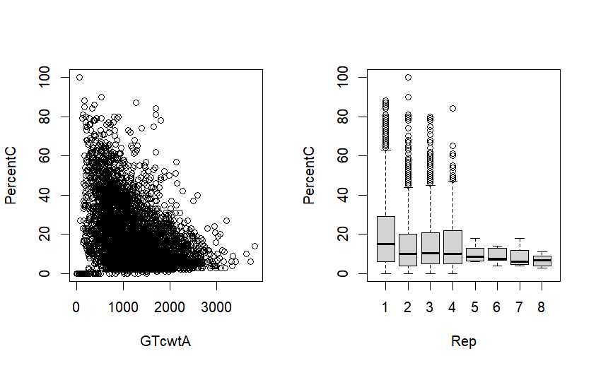

```r
par(mfrow = c(1,2))
plot(PercentC ~ GTcwtA, df)
df$Rep = as.factor(df$Rep)
plot(PercentC ~ Rep, df)
```

## 1.3 When to Use Regression Analysis

Regression is used for explaining the relationship between a single response variable (Y), and one or more predictor (X) variables

- **The response must be a continuous variable, but the predictors can be continuous, discrete, or categorical**

## 1.4 History

Francis Galton coined the term *regression to mediocrity* in 1875 in reference to the simple regression equation in the form:
$$\frac{y-\overline{y}}{SD_{y}}=r\frac{(x-\overline{x})}{SD_{x}}$$
Where *r* is the correlation between x and y

We scale each variable to have a mean of zero and SD of one. this simplifies the regression to:

$$y = rx$$

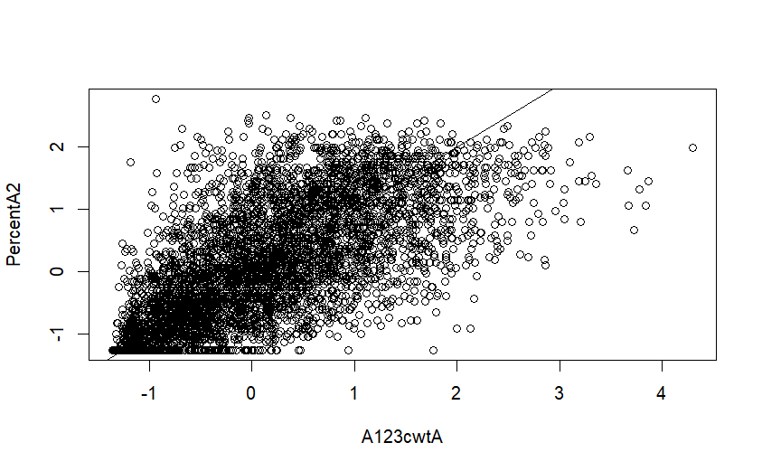

```r
dfScaled = data.frame(c(scale(df$PercentA2)), scale(df$A123cwtA))
colnames(dfScaled) <- c("PercentA2", "A123cwtA")
plot(PercentA2 ~ A123cwtA, dfScaled)
abline(0,1)
```

## Exercises

Make a numerical and graphical summary of the data

```r
summary(df)
```

```
     Plot                Rep            Trt          Trt 2
 Length:5290        1      :2481   Min.   :   0.0   Mode:logical
 Class :character   2      :1362   1st Qu.:   3.0   NA's:5290
 Mode  :character   3      :1046   Median :  27.0
                    4      : 369   Mean   : 171.2
                    5      :   8   3rd Qu.:  75.0
                    6      :   8   Max.   :2307.0
                    (Other):  16
     GTcwtA        A123cwtA         PercentC         PercentB
 Min.   :   0   Min.   :  0.00   Min.   :  0.00   Min.   :  0.00
 1st Qu.: 689   1st Qu.: 58.25   1st Qu.:  5.00   1st Qu.:  7.00
 Median :1127   Median :141.00   Median : 12.00   Median : 14.00
 Mean   :1140   Mean   :150.96   Mean   : 17.06   Mean   : 15.42
 3rd Qu.:1575   3rd Qu.:227.00   3rd Qu.: 25.00   3rd Qu.: 22.00
 Max.   :3827   Max.   :628.00   Max.   :100.00   Max.   :100.00

   PercentA1        PercentA2       PercentA3         Percent A4
 Min.   : 0.000   Min.   : 0.00   Min.   : 0.0000   Min.   :0.00000
 1st Qu.: 0.000   1st Qu.: 8.00   1st Qu.: 0.0000   1st Qu.:0.00000
 Median : 0.000   Median :26.00   Median : 0.0000   Median :0.00000
 Mean   : 2.789   Mean   :28.69   Mean   : 0.5329   Mean   :0.01115
 3rd Qu.: 0.000   3rd Qu.:47.00   3rd Qu.: 0.0000   3rd Qu.:0.00000
 Max.   :83.000   Max.   :92.00   Max.   :73.0000   Max.   :6.00000
 NA's   :14
  Percent A13     Percent A23          SG          PercentGreen
 Min.   : 0.00   Min.   : 0.00   Min.   :0.0000   Min.   : 0.0000
 1st Qu.: 9.00   1st Qu.: 8.00   1st Qu.:1.0650   1st Qu.: 0.0000
 Median :28.00   Median :26.00   Median :1.0740   Median : 0.0000
 Mean   :32.07   Mean   :29.22   Mean   :0.9484   Mean   : 0.4344
 3rd Qu.:52.00   3rd Qu.:47.00   3rd Qu.:1.0820   3rd Qu.: 0.0000
 Max.   :99.00   Max.   :96.00   Max.   :1.1100   Max.   :17.0000
 NA's   :14                      NA's   :2        NA's   :2
   PercentGC         PercentMis       PercentRots     PercentTotal PO
 Min.   : 0.0000   Min.   : 0.0000   Min.   : 0.000   Min.   : 0.000
 1st Qu.: 0.0000   1st Qu.: 0.0000   1st Qu.: 0.000   1st Qu.: 0.000
 Median : 0.0000   Median : 0.0000   Median : 2.000   Median : 3.000
 Mean   : 0.3476   Mean   : 0.7907   Mean   : 3.244   Mean   : 4.808
 3rd Qu.: 0.0000   3rd Qu.: 0.0000   3rd Qu.: 5.000   3rd Qu.: 7.000
 Max.   :24.0000   Max.   :49.0000   Max.   :53.000   Max.   :65.000
 NA's   :5         NA's   :5         NA's   :1        NA's   :13
   PercentHH          PercentCRS        PercentIHN         PercentBC
 Min.   :   0.000   Min.   : 0.0000   Min.   :  0.0000   Min.   : 0.0000
 1st Qu.:   0.000   1st Qu.: 0.0000   1st Qu.:  0.0000   1st Qu.: 0.0000
 Median :   0.000   Median : 0.0000   Median :  0.0000   Median : 0.0000
 Mean   :   1.996   Mean   : 0.2422   Mean   :  0.9134   Mean   : 0.4624
 3rd Qu.:   0.000   3rd Qu.: 0.0000   3rd Qu.:  0.0000   3rd Qu.: 0.0000
 Max.   :4100.000   Max.   :80.0000   Max.   :760.0000   Max.   :43.0000
```

See above plots for graphical summary

# Chapter 2 - Estimation

## 2.1 - Linear Model

A linear model can typically be simplified to the form:

$$Y = \beta_0 + \beta_1X_1 + \beta_2X_2 +
\beta_3X_3+ \varepsilon$$

Where $\beta_i, i = 0,1,2,3$ are unkown *parameters*. $\beta_0$ is called the *intercept term*. and $\varepsilon$ is the error.

In a linear model the *parameters enter linearly* - the predictors themselves do not have to be linear. For example:

$$Y = \beta_0 + \beta_1X_1 + \beta_2logX_2
+ \beta_3X_1X_2 + \varepsilon$$

is a linear model, but:

$$Y = \beta_0 + \beta_1X^{\beta_2}_1 +
\varepsilon$$

is not. Some relationships can be *transformed* to linearity - for example, $\beta_1X^{\beta_2}_1$ can be linearized by taking logs.

Linear models are very flexible. predictors can be transformed and combined in any way, and linear models can easily be expanded and modified to handle complex datasets.

Truly nonlinear models are rarely necessary and often arise from a theory about the relationships between the variables, rather than an empirical investigation

## 2.2 - Matrix Representation

if we have a response $Y$ and three predictors, $X1$, $X2$, and $X3$

the data might be presented in tabular form as such:

```r
library(kableExtra)

df2A2 <- t(data.frame(
  c('$$y_1$$', '$$x_{11}$$', '$$x_{12}$$', '$$x_{13}$$'),
  c('$$y_2$$', '$$x_{21}$$', '$$x_{22}$$', '$$x_{23}$$'),
  c('...', '', '...', ''),
  c('$$y_n$$', '$$x_{n1}$$', '$$x_{n2}$$', '$$x_{n3}$$')
                   ))
kbl(df2A2, row.names = FALSE) %>%
  kable_styling(bootstrap_options = "striped")
```

[output not shown]

where
$$n$$
is the number of observations, or *cases* in the dataset. Given the actual data values, we might write the model as:

$y_i = \beta_0 + \beta_{1x_i1} + \beta_{2x_i2} + \beta_{3x_i3} + \varepsilon\ \ \ \ \ \ \ \ \ \ \ i = 1,...,n$

But the use of subscripts becomes inconvenient. We will simplify it using a *matrix/vector* representation. The regression equation is written as:

$$y = X\beta + \varepsilon$$
Where $y = (y_1,...,y_n)^T$, $\varepsilon = (\varepsilon_1,...,\varepsilon_n)^T$, $\beta = (\beta_0,...,\beta_n)^T$ and:

$$X =
\left(\begin{array}{cccc}
1\ x_{11}\ x_{12}\ x_{13} \\1\ x_{11}\ x_{12}\ x_{13} \\... \ \ \ \ ...
\\1 \ x_{11}\ x_{12}\ x_{13}\end{array}\right)$$
The column of ones incorporates the intercept term. One simple example is the *null model* where there no is no predictor, but only a mean $y = \mu + \varepsilon$:

$$\left(\begin{array}{ccc}y \\
...\\y_n\end{array}\right)=\left(\begin{array}{ccc}1\\ ... \\
1\end{array}\right)\mu+\left(\begin{array}{ccc}\varepsilon_1 \\ ... \\
\varepsilon_n\end{array}\right)$$
We can assume that $E\varepsilon = 0$ because if this were not so, we could absorb the nonzero expectation for the error into the mean $\mu$ to get a zero expectation.

## 2.3 - Estimating $\beta$

The regression model $y = X\beta + \varepsilon$ splits the response into a *systematic component* $X\beta$ and a *random component* $\varepsilon$.

We want to choose $\beta$ so that the *systematic component* explains as much of the response as possible.

Geometrically speaking:

- The response lies in an $n$-dimensional space. that is, $y \in IR^n$ while $\beta \in IR^p$ where $p$ is the number of parameters.
- if we include the intercept then $p$ is the number of predictors plus one. We will use this definition of $p$ from now on.

$\hat{\beta}$, is, in this sense, the best estimate of $\beta$ within the model space.

The response predicted by the model is $\hat{y} = X\hat{\beta}$ or $Hy$ where $H$ is an *orthogonal projection matrix*.

The difference between the actua response and the predicted response is denoted by $\hat{\varepsilon}$ and called the *residuals*.

The goal here is to represent something complex: $y$, which is $n$-dimensional, in terms of something simpler: the model, which is $p$-dimensional.

If our model is successful, the structure in the data shold be captures in those $p$ dimensions, leaving just random variation in the residuals which lie in an $(n-p)$-dimensional space.

We have:

- Data = Systematic Structure + Random Variation
- $n$ dimensions = $p$ dimensions + $(n - p)$ dimensions

## 2.4 - Least Squares Estimation

The estimation of $\beta$ can also be considered from a nongeometrical point of view.

We might define the best estimate of $\beta$ as the one which minimizes the sum of the squared errors. the *least squares* estimate of $\beta$, called $\hat{\beta}$ minimizes:

$$\sum{\varepsilon^2_i} =
\varepsilon^T\varepsilon = (y - X\beta)^T(y-X\beta)$$

differentiationg with respect to $\beta$ and setting to 0, we find that $\hat{\beta}$ satisfies:

$$X^TX\hat{\beta} = X^Ty$$

these are called the *normal equations*. We can derive the same result using the geometrical approach. Provided $X^TX$ is invertible:

- $\hat{\beta} = (X^TX)^{-1}X^Ty$
- $X\hat{\beta} = X(X^TX)^{-1}X^Ty$
- $\hat{y} = Hy$

$H = X(X^TX)^{-1}X^T$ is called the *hat matrix* and is the orthogonal projection of $y$ onto the space spanned by $X$. $H$ is useful for theoretical manipulations, but it is not usually computed explicitly, as it is an $n$ x $n$ matrix which could be very large for some datasets.

The following useful quantities can now be represented using $H$

- The predicted or fitted values are $\hat{y} = Hy = X\hat{\beta}$
- The residuals are $\hat{\varepsilon} = y - X\hat{\beta} = y - \hat{y} = (I-H)y$
- The sun of squares (RSS) is $\hat{\varepsilon}^T\hat{\varepsilon} = y^T(I-H)^T(I-H)y = y^T(I-H)y$

The least squares estimate is the best possible estimate of $\beta$ when the errors $\varepsilon$ are uncorrelated and have equal variance. more briefly put:

- var $\varepsilon = \sigma^2I$

$\hat{\beta}$ is unbiased and has variance $(X^TX)^{-1}\sigma^2$ provided var $\varepsilon = \sigma^2I$. since $\hat{\beta}$ is a vector, its variance is a matrix.

We also need to estimate $\sigma^2$. we find that $E\hat{\varepsilon}^T\hat{\varepsilon} = \sigma^2(n-p)$, which suggests the estimator:

$\hat{\sigma}^2 = \frac{\hat{\varepsilon}^T\hat{\varepsilon}}{n-p} = \frac{RSS}{n-p}$

as an unbiased estimate of $\sigma^2$. $n - p$ is the *degrees of freedom* of the model.

- Sometimes you need the standard error of a particular component of $\hat{\beta}$ which can be picked out as $se(\hat{\beta}_{i-1})=\sqrt{(X^TX)_{ii}^{-1}\hat{\sigma}}$.

## 2.5 - Examples of Calculating $\hat{\beta}$

In a few simple models, it is possible to derive explicit formulae for $\hat{\beta}$:

1. When $y = \mu + \varepsilon$, $X = 1$ and $\beta = \mu$ so $X^TX = 1^T1 = n$ so:
- $\hat{\beta} = (X^TX)^{-1}X^Ty = \frac{1}{n}1^Ty = \bar{y}$
2. Simple linear regression (one predictor):
- $y_i = \beta_0 + \beta_1x_i + \varepsilon_i$
- $\left(\begin{array}{ccc}y_1\\...\\y_n\end{array}\right) = \left(\begin{array}{ccc}1\ \ \ \ \ \ x_1\\...\ \ \ \ \ \ \\1\ \ \ \ \ \ x_n\end{array}\right)\left(\begin{array}{cc}\beta_0\\\beta_1\end{array}\right) + \left(\begin{array}{ccc}\varepsilon_1\\...\\\varepsilon_n\end{array}\right)$

We can now apply the formula, but a simpler approach is to rewrite the equation as:

$y_i = \overbrace{\beta_0 + \beta_1\bar{x}}+\beta_1(x_i-\bar{x})+\varepsilon_i^{\beta'_0}$

so now:

$X = \left(\begin{array}{ccc}1\ \ \ x_1-\bar{x}\\...\ \ \ \ \ \ \ \ \ \ \ \\1\ \ \ \ \ \ x_n-\bar{x}\end{array}\right)$

$X^TX = \left(\begin{array}{cc}n\ \ \ \ \ \ \ \ \ \ \ \ \ \ \ \ \ \ \ \ \ \ \ \ \ 0 \\ 0\ \ \sum{}^n_{i=1}(x_i-\bar{x})^2\end{array}\right)$

Next work through the rest of the cauculation to reconstruct the familiar estimates, that is:

$\hat{\beta}_1 = \frac{\sum{(x_i-\bar{x})y_i}}{\sum{(x_i-\bar{x}})^2}$

In higher dimensions, computers are usually needed to find such explicit formulae for the parameter estimates unless $X^TX$ happens to be a simple form.

## 2.6 - Gauus-Markov Theorem

To understand the Gauss-Markov Theorem we first need to understand the concept of an *estimable function*. A linear combination of the parameters $\Psi = c^T\beta$ is an estimable if an only if there exists a linear combination $a^Ty$ such that:

$Ea^Ty = c^T\beta\ \ \ \ \ \forall\beta$

Whole bunch of math that im not writing - check the book.

The Gauss-Markov theorem shows that the least squares estimate $\hat{\beta}$ is a good choice, but it does require that the errors are uncorrelated and have equal variance.

Situations where estimators other than ordinary least squares should be considered are: - When the errors are correlated or have unequal variance, generalized least squares should be used. See section 6.1 - When the error distribution is long-tailed, then robust estimates might be used. Robust estimates are typically not linear in y. see section 6.4 - When the predictors are highly correlated (collinear), then biased estimators such as ridge regression might be preferable (see chapter 9)

## 2.7 - Goodness of Fit